# Rapport IF36 - Analyse des données des sons les plus écoutés sur Spotify en 2023, ainsi que leurs statistiques sur toutes les plateformes de streaming

Semestre : P24

Anna VALIER / Jeanne RAYNAUD / Antoine SAADA/ Rémy KINZELIN

2024-04-27

# Analyse des données des sons les plus écoutés sur Spotify en 2023 avec leurs statistiques sur toutes les plateformes de streaming, les musiques les moins écoutés sur la Plateforme toutes années confondu ainsi que les sons les plus écouter en 2022.

*Avant tout, nous tenons à vous informer que ce projet vise à élaborer un tableau de bord dynamique permettant d’analyser les données des musiques les plus écoutées et de créer divers graphiques à l’aide du langage R. Ce tableau de bord inclura également un système de filtrage interactif.*

## Présentation des datasets

### Les musiques les plus écoutés sur Spotify en 2023 avec leurs statistiques sur toutes les plateformes de streaming:

Lien de ce dataset : https://www.kaggle.com/datasets/nelgiriyewithana/top-spotify-songs-2023

Ce jeu de données a été publié par l’utilisateur Nidula Elgiriyewithana ⚡ sur Kaggle, qui est un utilisateur ordinaire de cette plateforme mais qui a fusionné plusieurs API telles que celle de Spotify : https://developer.spotify.com/documentation/web-api/reference/get-multiple-artists (mentionnée après qu’une personne a demandé la source des données dans les commentaires), ainsi que celles de Shazam, Deezer et Apple Music. Ce jeu de données est mis à jour annuellement. De nombreux correctifs ont été mis en place pour résoudre des problèmes depuis sa création, tels que des données erronées, des erreurs système, et autres.

### Les musiques les moins écoutés sur spotify toutes années confondu :

Lien de ce dataset : https://www.kaggle.com/datasets/estienneggx/spotify-unpopular-songs

Ce jeu de données a été publié par l’utilisateur ESTIENNEGGX sur Kaggle, qui est un utilisateur ordinaire de cette plateforme. Les données ont été récupérées en utilisant Python avec l’API de Spotify et la bibliothèque Spotipy. La méthodologie utilisée est la suivante : - Récupération des albums impopulaires (l’API de Spotify ne permet pas de récupérer directement les chansons impopulaires) - Récupération des identifiants des chansons à partir des albums - Récupération des caractéristiques audio des chansons. La dernière modification de ce jeu de données remonte à plus d’un an.

### Les musiques les plus écoutés sur Spotify en 2022 avec leurs statistiques sur toutes les plateformes de streaming:

Lien de ce dataset : https://www.kaggle.com/datasets/sveta151/spotify-top-chart-songs-2022?resource=download

Ce jeu de données a été publié par l’utilisateur SVETA151 sur Kaggle, qui est un utilisateur ordinaire de cette plateforme. Les données proviennent à l’origine de la plateforme “Top Chart Spotify Global”. Le “Top Chart Spotify Global” est une liste des chansons les plus populaires dans le monde entier, selon les statistiques de streaming sur la plateforme Spotify. Les données y sont régulièrement mises à jour.

## Pourquoi avons-nous choisi ce jeu de données ?

L’arrivée du streaming dans les années 2000 à transformé notre façon de consommer de la musique. L’auditeur d’aujourd’hui à un vaste choix d’artistes, d’albums, de style, de playlist simplement sur son téléphone et peut écouter sa musique partout même lorsqu’il n’a pas de connexion, cela compose une grande partie du marché de la musique. Il est également plus simple de se lancer dans la musique ainsi il y a beaucoup d’artistes. Si on se place du pdv d’une maison de disque, il peut être difficile de savoir qui signer ou non. En analysant les données des musiques les plus populaires peut être pouvons nous essayer d’établir ce qui plait le plus au consommateur sans pour autant s’attendre à une recette miracle, simplement observer les tendances et même peut être tenter de prévoir ce qui fonctionnera à l’avenir.

## Les données manipulées

### Les musiques plus écoutés sur Spotify en 2023 (spotify-2023.csv)

- **Attribut** : `track_name`
  - **Type de données** : chaîne de caractères
  - **Explication** : Nom de la chanson. Utile pour l’identification et la recherche de la chanson dans les bases de données et les plateformes de streaming.
- **Attribut** : `artist(s)_name`
  - **Type de données** : chaîne de caractères
  - **Explication** : Nom de l’artiste(s) de la chanson. Permet d’analyser la popularité et le style de l’artiste associé à la chanson.
- **Attribut** : `artist_count`
  - **Type de données** : entier
  - **Explication** : Nombre d’artistes participants sur le titre. Peut indiquer des collaborations et des influences multiples sur la chanson.
- **Attribut** : `released_year`
  - **Type de données** : entier
  - **Explication** : L’année de sortie de la chanson. Permet d’étudier les tendances musicales au fil du temps et de comparer la performance des chansons dans différentes périodes.
- **Attribut** : `released_month`
  - **Type de données** : entier
  - **Explication** : Le mois de sortie de la chanson. Peut être utilisé pour analyser les saisonsnalités et les tendances saisonnières dans la musique.
- **Attribut** : `released_day`
  - **Type de données** : entier
  - **Explication** : Le jour de sortie de la chanson. Peut être pertinent pour étudier les stratégies de lancement de chansons.
- **Attribut** : `in_spotify_playlists`
  - **Type de données** : entier
  - **Explication** : Nombre de playlists Spotify dans lesquelles la chanson est présente. Indique la popularité et la portée de la chanson sur la plateforme Spotify.
- **Attribut** : `in_spotify_charts`
  - **Type de données** : entier
  - **Explication** : Nombre de fois où la chanson est apparue dans les classements Spotify. Révèle la popularité et la tendance de la chanson sur Spotify.
- **Attribut** : `streams`
  - **Type de données** : entier
  - **Explication** : Nombre de streams sur Spotify. Mesure la popularité et l’engagement des auditeurs avec la chanson sur Spotify.
- **Attribut** : `in_apple_playlists`
  - **Type de données** : entier
  - **Explication** : Nombre de playlists Apple Music dans lesquelles la chanson est présente. Indique la popularité de la chanson sur Apple Music.
- **Attribut** : `in_apple_charts`
  - **Type de données** : entier
  - **Explication** : Nombre de fois où la chanson est apparue dans les classements Apple Music. Révèle la popularité et la tendance de la chanson sur Apple Music.
- **Attribut** : `in_deezer_playlists`
  - **Type de données** : entier
  - **Explication** : Nombre de playlists Deezer dans lesquelles la chanson est présente. Indique la popularité de la chanson sur Deezer.
- **Attribut** : `in_deezer_charts`
  - **Type de données** : entier
  - **Explication** : Nombre de fois où la chanson est apparue dans les classements Deezer. Révèle la popularité et la tendance de la chanson sur Deezer.
- **Attribut** : `in_shazam_charts`
  - **Type de données** : entier
  - **Explication** : Nombre de fois où la chanson est apparue dans les classements Shazam. Peut indiquer la popularité émergente de la chanson.
- **Attribut** : `bpm`
  - **Type de données** : entier
  - **Explication** : Le nombre de battements par minute de la chanson, indiquant le tempo. Permet de classifier le style et le genre de la chanson.
- **Attribut** : `key`
  - **Type de données** : chaîne de caractères
  - **Explication** : La clé musicale dans laquelle la chanson est jouée. Utile pour l’analyse harmonique et la comparaison avec d’autres chansons.
- **Attribut** : `mode`
  - **Type de données** : chaîne de caractères
  - **Explication** : Le mode musical de la chanson, majeur ou mineur. Influence l’émotion et l’atmosphère perçue de la chanson.
- **Attribut** : `danceability_%`
  - **Type de données** : entier
  - **Explication** : Pourcentage indiquant à quel point une chanson est adaptée à la danse. Utile pour comprendre l’aspect rythmique et l’attrait pour la danse.
- **Attribut** : `valence_%`
  - **Type de données** : entier
  - **Explication** : Pourcentage reflétant la positivité transmise par la chanson. Peut être utilisé pour analyser le sentiment et l’humeur de la chanson.
- **Attribut** : `energy_%`
  - **Type de données** : entier
  - **Explication** : Pourcentage mesurant l’intensité et l’activité de la chanson. Indique le niveau d’énergie perçu de la chanson.
- **Attribut** : `acousticness_%`
  - **Type de données** : entier
  - **Explication** : Pourcentage indiquant à quel point une chanson est acoustique. Utile pour distinguer les enregistrements acoustiques des enregistrements électroniques.
- **Attribut** : `instrumentalness_%`
  - **Type de données** : entier
  - **Explication** : Pourcentage estimant la quantité de la chanson qui est instrumentale. Peut aider à identifier les chansons avec peu ou pas de voix.
- **Attribut** : `liveness_%`
  - **Type de données** : entier
  - **Explication** : Pourcentage détectant la présence d’un public dans l’enregistrement. Indique si la chanson a été enregistrée en direct ou en studio.
- **Attribut** : `speechiness_%`
  - **Type de données** : entier
  - **Explication** : Pourcentage qui identifie la présence de paroles parlées dans une chanson. Utile pour distinguer les chansons chantées des chansons parlées.

### Les musiques les moins écoutés sur spotify (unpopular_songs.csv et z_genre_of_artists.csv)

- **Attribut** : `danceability`
  - **Type de données** : float
  - **Explication** : Indique à quel point une chanson est adaptée à la danse. Utile pour comprendre l’aspect rythmique et l’attrait pour la danse.
- **Attribut** : `energy`
  - **Type de données** : float
  - **Explication** : L’intensité et l’activité de la chanson. Indique le niveau d’énergie perçu de la chanson.
- **Attribut** : `key`
  - **Type de données** : float
  - **Explication** : La clé musicale dans laquelle la chanson est jouée. Utile pour l’analyse harmonique et la comparaison avec d’autres chansons.
- **Attribut** : `loudness`
  - **Type de données** : float
  - **Explication** : L’intensité sonore globale d’une chanson en décibels (dB).
- **Attribut** : `mode`
  - **Type de données** : float
  - **Explication** : Le mode musical de la chanson, majeur ou mineur. Influence l’émotion et l’atmosphère perçue de la chanson.
- **Attribut** : `speechiness`
  - **Type de données** : float
  - **Explication** : La présence de paroles parlées dans une chanson. Utile pour distinguer les chansons chantées des chansons parlées.
- **Attribut** : `acousticness`
  - **Type de données** : float
  - **Explication** : Indique la proportion d’accoustique d’une chanson. Utile pour distinguer les enregistrements acoustiques des enregistrements électroniques.
- **Attribut** : `instrumentalness`
  - **Type de données** : float
  - **Explication** : Indique la quantité de la chanson qui est instrumentale. Peut aider à identifier les chansons avec peu ou pas de voix.
- **Attribut** : `liveness`
  - **Type de données** : float
  - **Explication** : Détection de la présence d’un public dans l’enregistrement. Indique si la chanson a été enregistrée en direct ou en studio.
- **Attribut** : `valence`
  - **Type de données** : float
  - **Explication** : Indique la positivité transmise par la chanson. Peut être utilisé pour analyser le sentiment et l’humeur de la chanson.
- **Attribut** : `tempo`
  - **Type de données** : numeric
  - **Explication** : Le tempo de la chanson en battements par minute (BPM).
- **Attribut** : `duration_ms`
  - **Type de données** : numeric
  - **Explication** : La durée de la chanson en millisecondes.
- **Attribut** : `explicit`
  - **Type de données** : logical
  - **Explication** : Indique si la chanson contient un langage explicite.
- **Attribut** : `popularity`
  - **Type de données** : integer
  - **Explication** : La popularité de la chanson sur la plateforme Spotify.
- **Attribut** : `track_name`
  - **Type de données** : character
  - **Explication** : Le nom de la chanson.
- **Attribut** : `track_artist`
  - **Type de données** : character
  - **Explication** : L’artiste de la chanson.
- **Attribut** : `track_id`
  - **Type de données** : character
  - **Explication** : L’identifiant unique de la chanson sur Spotify.

### Les musiques les plus écoutés sur spotify en 2022 (spotify_top_charts_22.csv)

- **Attribut** : `uri`
  - **Type de données** : Chaîne de caractères
  - **Explication** : URI de la chanson.
- **Attribut** : `artist_names`
  - **Type de données** : Chaîne de caractères
  - **Explication** : Nom de l’artiste.
- **Attribut** : `track_name`
  - **Type de données** : Chaîne de caractères
  - **Explication** : Nom de la chanson.
- **Attribut** : `peak_rank`
  - **Type de données** : Entier
  - **Explication** : Classement maximal obtenu par la chanson.
- **Attribut** : `weeks_on_chart`
  - **Type de données** : Entier
  - **Explication** : Nombre de semaines dans les classements des meilleurs sons.
- **Attribut** : `danceability`
  - **Type de données** : Réel
  - **Explication** : La danseabilité décrit à quel point une piste est adaptée à la danse en fonction d’une combinaison d’éléments musicaux comprenant le tempo, la stabilité du rythme, la force du rythme et la régularité globale. Une valeur de 0.0 est la moins adaptée à la danse et 1.0 est la plus adaptée.
- **Attribut** : `energy`
  - **Type de données** : Réel
  - **Explication** : L’énergie est une mesure de 0.0 à 1.0 et représente une mesure perceptive de l’intensité et de l’activité.
- **Attribut** : `key`
  - **Type de données** : Entier
  - **Explication** : La tonalité dans laquelle la piste se trouve. Les entiers sont associés aux notes en utilisant la notation standard des classes de hauteur.
- **Attribut** : `loudness`
  - **Type de données** : Réel
  - **Explication** : La loudness est la qualité d’un son qui est corrélée avec l’amplitude. Les valeurs se situent généralement entre -60 et 0 dB.
- **Attribut** : `mode`
  - **Type de données** : Entier
  - **Explication** : Le mode indique la modalité (majeure ou mineure) d’une piste, le type de gamme à partir de laquelle son contenu mélodique est dérivé. La majeure est représentée par 1 et la mineure par 0.
- **Attribut** : `speechiness`
  - **Type de données** : Réel
  - **Explication** : La parole détecte la présence de mots parlés dans une piste. Plus la valeur est proche de 1.0, plus l’enregistrement est parlé.
- **Attribut** : `acousticness`
  - **Type de données** : Réel
  - **Explication** : Une mesure de confiance de 0.0 à 1.0 quant à savoir si la piste est acoustique.
- **Attribut** : `instrumentalness`
  - **Type de données** : Réel
  - **Explication** : Détecte la place de l’instrumental dans un son. Plus la valeur est proche de 1.0, plus le son est considéré comme instrumental (moins il y a de contenu vocal).
- **Attribut** : `liveness`
  - **Type de données** : Réel
  - **Explication** : Détecte la présence d’un public dans l’enregistrement.
- **Attribut** : `tempo`
  - **Type de données** : Réel
  - **Explication** : Le tempo estimé global d’une piste en battements par minute (BPM).
- **Attribut** : `time_signature`
  - **Type de données** : Entier
  - **Explication** : La signature temporelle (ou mesure) est une convention de notation qui spécifie combien de temps (ou battements) il y a dans chaque mesure.
- **Attribut** : `duration_ms`
  - **Type de données** : Entier
  - **Explication** : La durée de la piste en millisecondes.

## Nos problématiques :

### Problématique :

Existe-t-il des différences significatives dans les chansons les plus populaires sur chaque plateforme ?

#### Explication :

Pour répondre à cette problématique, nous allons utiliser les données suivantes : - **Inclusion dans les playlists et les classements** : Nous examinerons le nombre de playlists et les classements sur chaque plateforme (Spotify, Apple Music, Deezer, Shazam) dans lesquels une chanson est présente. - **Nombre total de streams** : Nous comparerons le nombre total de streams sur chaque plateforme pour évaluer la popularité relative des chansons. - **Caractéristiques audio** : Nous analyserons les caractéristiques audio telles que le tempo, l’énergie, la positivité musicale, etc., pour comprendre les préférences des utilisateurs sur chaque plateforme. - **Variations temporelles** : Nous étudierons les tendances temporelles dans les classements et la popularité des chansons pour identifier toute fluctuation significative sur chaque plateforme au fil du temps.

#### Est ce qu’une application est plus influente que les autres?

Selon les musiques qu’elle met en playlist et le classement parmi les musiques les plus écoutées sur la plateforme. On espère pouvoir observer qu’une plateforme se démarque des autres mais il est possible qu’il n’y ait pas forcément de différence significative qui nous permettent d’établir la supériorité d’une plateforme par rapport aux autres en termes d’influence. Les variables que nous souhaitons utiliser sont les suivantes: - in_spotify_playlists: Number of Spotify playlists the song is included in - in_spotify_charts: Presence and rank of the song on Spotify charts - streams: Total number of streams on Spotify - in_apple_playlists: Number of Apple Music playlists the song is included in - in_apple_charts: Presence and rank of the song on Apple Music charts - in_deezer_playlists: Number of Deezer playlists the song is included in - in_deezer_charts: Presence and rank of the song on Deezer charts

Nous pouvons comparer le nombre de playlists dans lesquelles une ou plusieurs chansons (nous n’allons peut-être pas toutes les comparer), que nous aurons sélectionné au préalable (nous n’avons pas encore établi selon quels critères), sont présentes selon chaque plateforme de streaming. Nous pouvons également comparer la place de la chanson dans le classement des musiques pour chaque plateforme et voir si la présence de cette chanson en playlist a une influence sur son classement et ainsi voir sur quelle plateforme elle est la plus populaire. Le manque de données sur le nombre total de streams sur les plateformes Apple Music et Deezer est une vraie limite, puisque nous aurions pu le comparer avec Spotify, De plus si nous avions eu aussi le nombre total d’utilisateurs de chaque plateforme nous aurions pu étayer notre analyse en prenant en considération ces informations.

### L’ambiance de la musique nous dit-elle quelque chose sur la popularité d’une musique? ou Est ce qu’une ambiance de musique est particulièrement populaire?

Autrement dit: observons nous la présence d’une ambiance en majorité parmi les chansons les plus populaires de 2023? Par ambiance nous entendons l’atmosphère qui se dégage de la musique, ce que l’on ressent en l’écoutant. Pour ce faire nous pourrons établir différentes catégories distinctes, différentes ambiances. Chacune sera définie par des critères en utilisant notre jeu de données (pas encore totalement établies). Pour établir ces critères nous utiliserons ces données: - mode: Mode of the song (major or minor) - danceability_%: Percentage indicating how suitable the song is for dancing - valence_%: Positivity of the song’s musical content - energy_%: Perceived energy level of the song

Nous observerons pour chaque catégorie le mode puisqu’en musique le mode mineur est considéré comme plus triste tandis que le mode majeur comme joyeux. Ensuite nous établirons des plages de pourcentages de dansabilité, de positivité et d’énergie pour chaque catégorie. Une fois que nous aurons établies ces ambiances nous pourrons trier les chansons et comparer les nombre de chansons dans chaque catégorie et définir si oui ou non une catégorie est plus représentée. Nous supposons que les musiques festives et joyeuses pourraient être les plus représentées dans le classement des musiques les plus populaires de 2023.

### Le tempo d’une musique joue-t-il un rôle important dans la popularité de celle-ci ?

Ici nous nous demandons simplement si une plage de tempo est particulièrement représentée dans notre jeu de donné. Nous utiliserons uniquement la donnée du bpm. - bpm: Beats per minute, a measure of song tempo

Nous comparerons les bpm des chanson les plus populaires en 2023 puis nous introniserons les bpm les plus populaires.

#### Exploration

[figure not shown]

```r
# Sélectionner les 1000 premières chansons les plus populaires
top_songs <- spotify_data %>%
  arrange(desc(streams)) %>%
  slice(1:1000)

# Créer des intervalles de BPM
top_songs <- mutate(top_songs, bpm_interval = cut(bpm, breaks = c(0, 50, 100, 150, 200, 250)))

# Compter le nombre de chansons dans chaque intervalle
bpm_counts <- count(top_songs, bpm_interval)

# Créer le graphique à barres
ggplot(bpm_counts, aes(x = bpm_interval, y = n, fill = bpm_interval)) +
  geom_bar(stat = "identity") +
  scale_x_discrete(labels = c("0-50", "50-100", "100-150", "150-200", "200-250")) +
  labs(x = "Intervalles de BPM", y = "Nombre de chansons", title = "Répartition des BPM des 1000 premières chansons populaires") + theme_minimal() + scale_fill_brewer(palette = "Set2")
```

**Analyse :**

### Les auditeurs valorisent-ils plus les paroles ou l’instrumental d’une musique?

Nous comparerons la proportion de paroles dans une musique et verrons ce qui plait le plus en 2023. Pour cela nous utiliserons ces deux données: - instrumentalness_%: Amount of instrumental content in the song - speechiness_%: Amount of spoken words in the song

Cela nous permettra de savoir si un artiste doit plutôt investir dans l’instrumental ou dans les paroles. Malheureusement dans cette analyse nous ne pouvons pas évaluer la qualité des paroles (qui peut d’ailleurs être subjective), un pourcentage élevé de mots ne signifie pas forcément une richesse dans l’écriture non plus, cela peut simplement être la répétition d’un refrain par exemple, ce que nous ne pouvons établir non plus avec ce jeu de données.

#### Exploration

```r
spot_data_clean <- spotify_data %>% filter(!is.na(as.numeric(streams)))
```

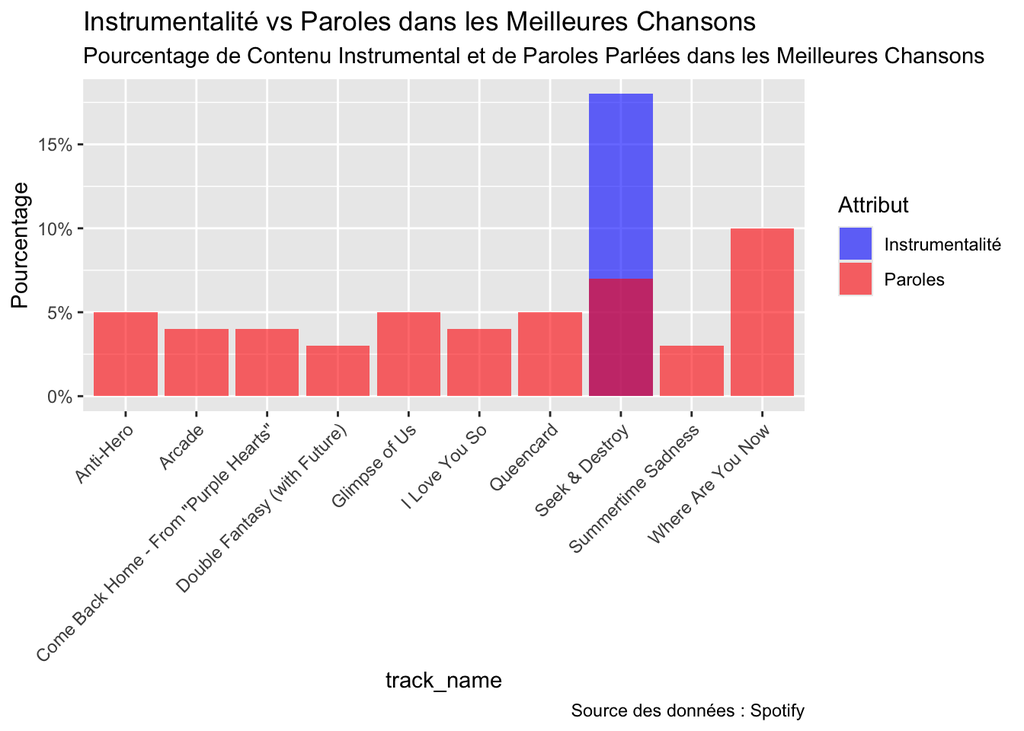

```r
best_songs <- spot_data_clean%>% arrange(desc(streams)) %>% slice(1:10)

# Diviser les pourcentages par 100 pour les ramener à une échelle de 0 à 1
best_songs$instrumentalness_pct <- best_songs$`instrumentalness_%` / 100
best_songs$speechiness_pct <- best_songs$`speechiness_%` / 100

# Créer le graphique à barres
ggplot(best_songs, aes(x = track_name)) +
  geom_bar(aes(y = instrumentalness_pct, fill = "Instrumentalité"), stat = "identity", alpha = 0.6, position = "dodge") +
  geom_bar(aes(y = speechiness_pct, fill = "Paroles"), stat = "identity", alpha = 0.6, position = "dodge") +
  labs(y = "Pourcentage", title = "Instrumentalité vs Paroles dans les Meilleures Chansons",
       subtitle = "Pourcentage de Contenu Instrumental et de Paroles Parlées dans les Meilleures Chansons",
       caption = "Source des données : Spotify") +
  scale_fill_manual(name = "Attribut", values = c("Instrumentalité" = "blue", "Paroles" = "red")) +
  scale_y_continuous(labels = scales::percent_format(accuracy = 1)) +
  theme(axis.text.x = element_text(angle = 45, hjust = 1))
```

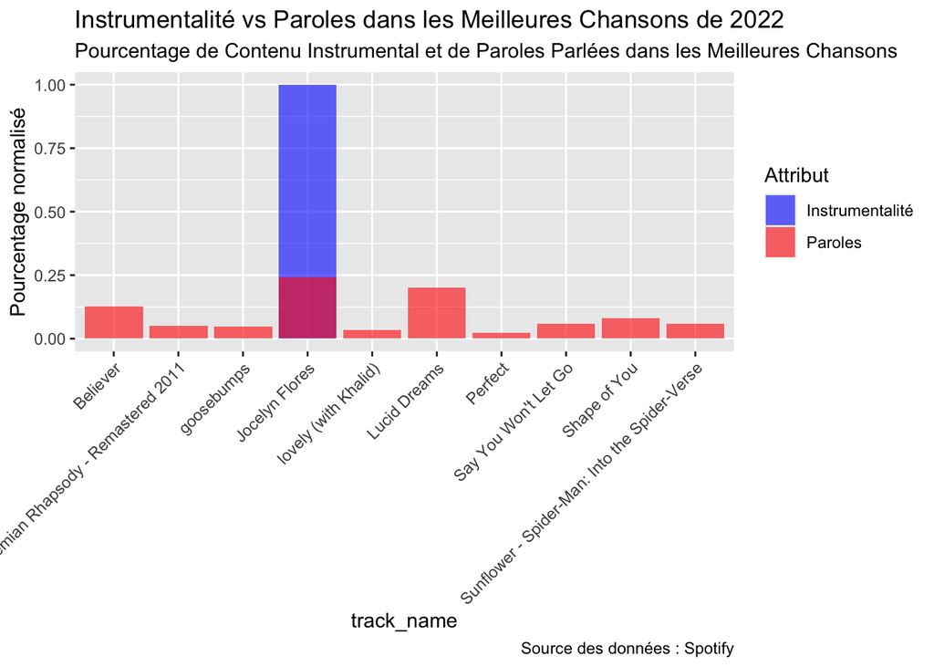

```r
spot_data_clean <- spotify22_data %>% filter(!is.na(as.numeric(weeks_on_chart)))
best_songs <- spot_data_clean %>%
  arrange(desc(weeks_on_chart)) %>%
  slice(1:10)

# Normalisation de speechiness et instrumentalness
best_songs <- best_songs %>%
  mutate(instrumentalness_pct = instrumentalness / max(instrumentalness),
         speechiness_pct = speechiness)

# Création du graphique
ggplot(best_songs, aes(x = track_name)) +
  geom_bar(aes(y = instrumentalness_pct, fill = "Instrumentalité"), stat = "identity", alpha = 0.6, position = "dodge") +
  geom_bar(aes(y = speechiness_pct, fill = "Paroles"), stat = "identity", alpha = 0.6, position = "dodge") +
  labs(y = "Pourcentage normalisé", title = "Instrumentalité vs Paroles dans les Meilleures Chansons de 2022",
       subtitle = "Pourcentage de Contenu Instrumental et de Paroles Parlées dans les Meilleures Chansons",
       caption = "Source des données : Spotify") +
  scale_fill_manual(name = "Attribut", values = c("Instrumentalité" = "blue", "Paroles" = "red")) +
  theme(axis.text.x = element_text(angle = 45, hjust = 1))
```

**Analyse :**

Sans trop de surprise on remarque une nette préférence chez les auditeurs pour des musiques comportant des paroles comparé aux morceaux purement instrumentaux. Ainsi il vaut mieux pour une maison de disque produire des chanteurs que des simples musiciens, si bien sûr c’est l’aspect commercial et économique qui les intéresse le plus.

Malheureusement dans cette analyse nous ne pouvons pas évaluer la qualité des paroles (qui peut d’ailleurs être subjective), un pourcentage élevé de mots ne signifie pas forcément une richesse dans l’écriture non plus, cela peut simplement être la répétition d’un refrain par exemple, ce que nous ne pouvons établir non plus avec ce jeu de données.

### Pouvons nous évaluer la taille et l’engagement de la fanbase d’un artiste?

Dans notre jeu de données nous pouvons voir le nom des artistes qui ont sorti les musiques ainsi nous pouvons supposer que si des artistes reviennent souvent dans le classement, c’est qu’ils ont des auditeurs qui sont investis et reviennent souvent les écouter et n’écoutent pas qu’une chanson toute la discographie de l’artiste. Nous utiliserons ces données: - artist(s)_name: Name of the artist(s) of the song - artist_count: Number of artists contributing to the song - in_spotify_playlists: Number of Spotify playlists the song is included in - in_spotify_charts: Presence and rank of the song on Spotify charts - streams: Total number of streams on Spotify - in_apple_playlists: Number of Apple Music playlists the song is included in - in_apple_charts: Presence and rank of the song on Apple Music charts - in_deezer_playlists: Number of Deezer playlists the song is included in - in_deezer_charts: Presence and rank of the song on Deezer charts - in_shazam_charts: Presence and rank of the song on Shazam charts

Nous pouvons pour estimer l’engagement des auditeurs regarder si les featurings sur lesquels l’artiste apparaît sont aussi bcp écoutés. Par exemple, si il y a deux artistes sur une musique et que l’un des deux artistes est présent plusieurs fois dans le classement des musiques les plus populaires, nous pouvons supposer que ce sont ses fans plus que celui de l’autre artiste qui ont permis à cette chanson de se retrouver dans ce classement.

On peut également supposer que si un artiste n’est présent qu’une seule fois dans ce classement c’est parce qu’une de ses chansons à eu du succès auprès du grand public d’une manière générale, mais qu’il n’a pas forcément une grosse fanbase qui écoute toutes ses musiques dès qu’elles sortent. En observant la présence d’une musique en playlist nous pouvons voir si la musique à été poussée vers l’auditeur ou si sans être beaucoup en playlist elle a réussi à être populaire. De plus avec la présence de la musique sur shazam nous pouvons peut être établir si des gens qui n’étaient pas familier avec l’artiste l’ont découvert en écoutant la radio, ou alors en soirée, puisque lorsqu’on shazam une musique c’est souvent qu’on entend cette musique par hasard et qu’elle nous sans que l’on soit des grands connaisseurs de l’artiste, donc cela pourrait être le signe que l’artiste à bbcp ou pas de nouveaux auditeurs.

Seulement si on avait la liste du nombre d’auditeurs mensuels moyens des artistes de spotify nous pourrions avoir une idée plus claire de l’engagement des auditeurs envers un artiste. De plus, il est aussi possible qu’une musique n’ait pas été populaire parce qu’elle était en playliste mais qu’elle ait été en playlist parce qu’elle était déjà populaire. Nous ne savons pas dans quel ordre cela se fait.

### Quelle place l’acoustique a-t-il dans la musique? Est ce populaire de nos jours?

On sait qu’il y a pleins de façons de faire de la musique et que la plupart des sons sont mixés. On utilise de nombreux outils qui peuvent modifier la voix, compléter les instruments ou parfois même les remplacer. Ce n’est d’ailleurs pas nouveau, la musique électronique date des années 50, ainsi nous voudrions simplement savoir si, et dans quelle proportion, les sons acoustiques ou alors des chansons totalement acoustiques ont une place dans le paysage musicale mainstream. Nous utiliserons pour savoir cela ces données: - acousticness_%: Amount of acoustic sound in the song - instrumentalness_%: Amount of instrumental content in the song

Nous supposons qu’il est peu probable que nous trouvions dans ce classement des musiques 100% acoustique, nous ne serions, au contraire, pas surpris de trouver de nombreuses chansons à 0%. Nous pensons qu’une majorité des chansons auront une part acoustique inférieure à 50%.

### Quel titre de musique a eu le plus de succès selon sa date de sortie ?

Pour identifier le titre de musique ayant eu le plus de succès selon sa date de sortie, nous pouvons utiliser les données suivantes :

- track_name
- artist(s)_name
- released_year
- released_month
- released_day
- streams

Pour mettre en avant les titres les plus écoutés selon leur date de sortie, nous pouvons procéder comme suit :

**1. Visualiser les meilleurs titres par année :** Nous pouvons regrouper les titres par année de sortie et identifier celui ayant reçu le plus grand nombre d’écoutes chaque année.

**2. Visualiser les meilleurs titres par mois :** De même, nous pouvons analyser les tendances mensuelles en regroupant les titres par mois de sortie et en identifiant les plus populaires pour chaque mois.

**3. Visualiser les meilleurs titres par jour :** Enfin, nous pouvons examiner les performances des titres en fonction des jours de sortie, en identifiant les titres les plus écoutés chaque jour. Ces analyses nous permettront de mettre en lumière les titres les plus populaires selon différents découpages temporels, offrant ainsi un aperçu précieux des préférences d’écoute du public au fil du temps.

### Existe-t-il une influence entre le rythme et la saison ?

En utilisant les données de BPM (battements par minute) fournies, nous pourrions examiner comment le rythme des musiques varie selon les saisons de l’année. Par exemple, nous pourrions regrouper les musiques selon leur saison de sortie et calculer la moyenne du BPM pour chaque saison. Cela nous permettrait de déterminer s’il existe des variations significatives dans le rythme des musiques en fonction des saisons.

Pour cette étude, nous utiliserions les données suivantes :

- released_month
- bpm

Nous pourrions alors supposer que cette étude pourrait démontrer que les musiques plus rythmées sont une tendance plus marquée pendant les saisons estivales.

#### Exploration

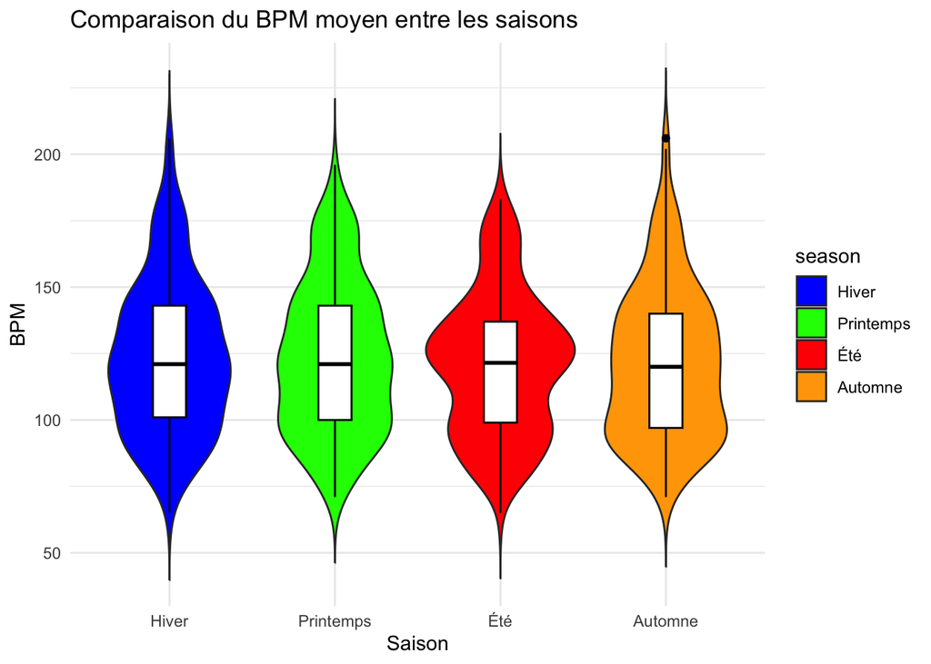

```r
couleurs <- c("Hiver" = "blue", "Printemps" = "green", "Été" = "red", "Automne" = "orange")

# Sélectionner les chansons les plus populaires (par exemple, les 1000 chansons avec le plus grand nombre de streams)
top_songs <- spotify_data %>%
  arrange(desc(streams)) %>%
  slice(1:1000)


# Comparaison du BPM moyen entre les saisons
ggplot(top_songs, aes(x = season, y = bpm, fill = season)) +
  geom_violin(trim = FALSE) +
  geom_boxplot(width = 0.2, fill = "white", color = "black") +
  labs(title = "Comparaison du BPM moyen entre les saisons",
       x = "Saison",
       y = "BPM") +
  scale_fill_manual(values = c("Hiver" = "blue", "Printemps" = "green", "Été" = "red", "Automne" = "orange")) +
  theme_minimal()
```

**Analyse :**

Le graphique illustre une comparaison claire des **BPM moyens** entre les saisons : **Hiver**, **Printemps**, **Été** et **Automne**. Chaque saison est représentée par une couleur différente et présente une forme de distribution distincte. Les boîtes à moustaches superposées sur les violons indiquent la médiane et les quartiles pour chaque saison.

### Existe-t’il des caractéristiques audio communes dans les sons populaires en fonction des saisons ?

Pour explorer l’existence de caractéristiques audio communes dans les morceaux populaires en fonction des saisons, nous pourrions suivre une approche analytique qui implique l’utilisation des données audio fournies telles que le BPM, la tonalité, le mode, ainsi que les caractéristiques telles que la danceability, la valence, l’énergie, etc. Voici comment nous pourrions procéder :

**1. Regroupement des titres par saison :** - Nous regrouperont les titres en fonction de leur date de sortie pour chaque saison de l’année.

**2. Analyse des caractéristiques audio :** - Nous analyserons les caractéristiques audio des titres les plus populaires pour chaque saison. Cela pourrait inclure des mesures telles que le BPM, la tonalité, le mode, ainsi que des caractéristiques plus subjectives comme la danceability, la valence, l’énergie, etc.

**3. Comparaison entre les saisons :** - Nous comparerons ensuite les caractéristiques audio des titres les plus populaires entre les différentes saisons. Nous chercherons des tendances ou des similarités dans les caractéristiques audio des morceaux qui sont populaires à des moments spécifiques de l’année.

**4. Interprétation des résultats :** Enfin, nous interpréterons les résultats pour déterminer s’il existe des caractéristiques audio communes dans les morceaux populaires en fonction des saisons. Cela pourrait nous aider à identifier des tendances saisonnières dans les préférences d’écoute du public en ce qui concerne le style musical, le rythme et l’ambiance des morceaux.

Pour réaliser cette étude, nous allons avoir besoin des données suivantes :

- released_year
- released_month
- released_day
- streams
- bpm
- key
- mode
- danceability_%
- valence_%
- energy_%
- acousticness_%
- instrumentalness_%
- liveness_%
- speechiness_%

En suivant cette méthodologie, nous pourrions obtenir des informations intéressantes sur la relation entre les caractéristiques audio des morceaux de musique et les saisons de l’année, ce qui pourrait être utile en tant que professionnel de l’industrie musicale dans la création et la promotion de musique adaptée à chaque période de l’année.

#### Exploration

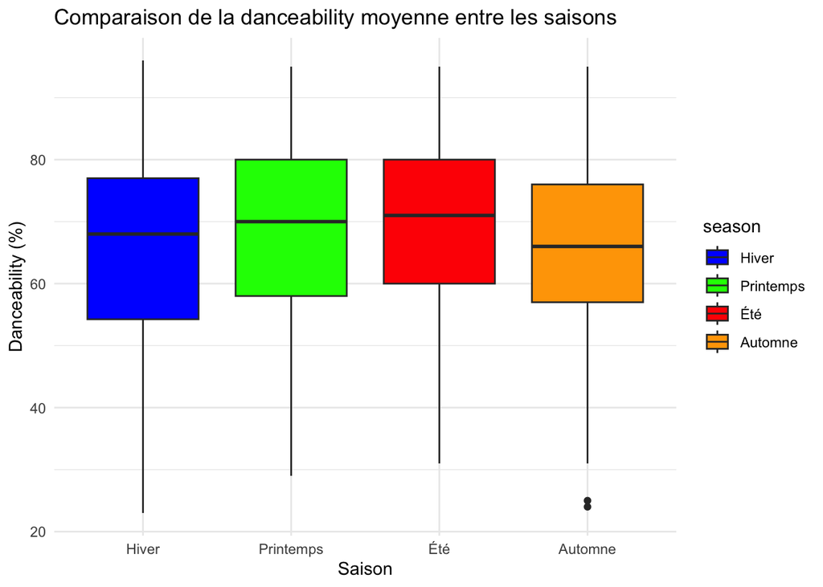

```r
# Graphique : Comparaison de la danceability moyenne entre les saisons
ggplot(top_songs, aes(x = season, y = `danceability_%`, fill = season)) +
  geom_boxplot() +
  scale_fill_manual(values = couleurs)+
  labs(title = "Comparaison de la danceability moyenne entre les saisons",
       x = "Saison",
       y = "Danceability (%)") +
  theme_minimal()
```

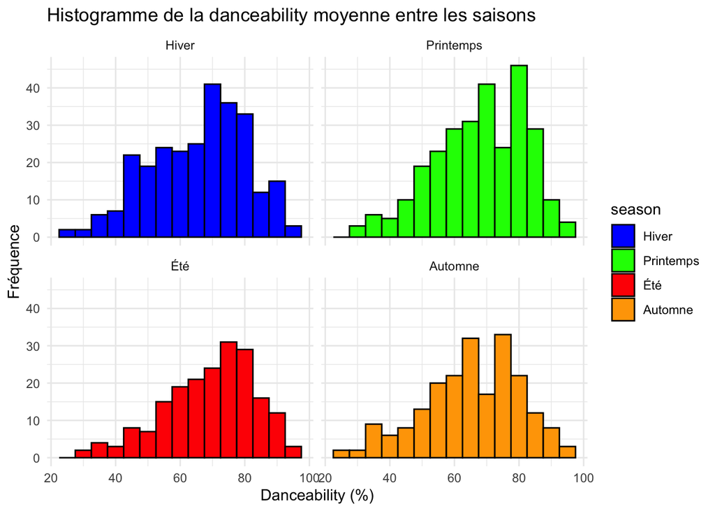

```r
ggplot(spotify_data, aes(x = `danceability_%`, fill = season)) +
  geom_histogram(binwidth = 5, color = "black", position = "dodge") +
  scale_fill_manual(values = couleurs) +
  labs(title = "Histogramme de la danceability moyenne entre les saisons",
       x = "Danceability (%)",
       y = "Fréquence") +
  facet_wrap(~season) +
  theme_minimal()
```

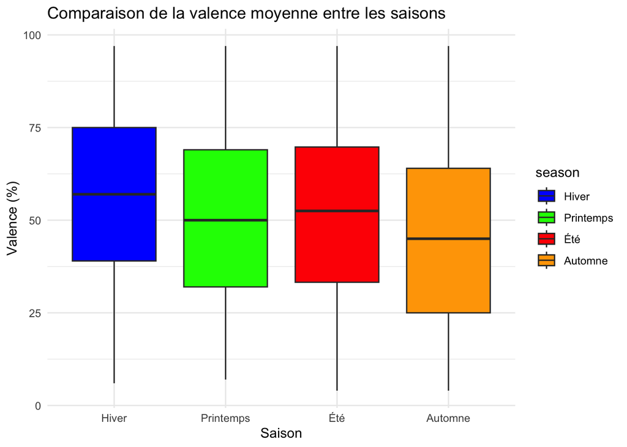

```r
# Graphique : Comparaison de la valence moyenne entre les saisons
ggplot(top_songs, aes(x = season, y = `valence_%`, fill = season)) +
  geom_boxplot() +scale_fill_manual(values = couleurs)+
  labs(title = "Comparaison de la valence moyenne entre les saisons",
       x = "Saison",
       y = "Valence (%)") +
  theme_minimal()
```

De même, la valence moyenne est plus élevée pendant la saison d’hiver, ce qui suggère une préférence pour des chansons avec une ambiance plus positive et joyeuse pendant cette période. À l’inverse, la valence moyenne est plus basse en automne, ce qui pourrait refléter une atmosphère plus mélancolique ou introspective associée à cette saison.

Cependant, il est important de noter que ces observations peuvent être influencées par la présence de données aberrantes ou une distribution asymétrique des valeurs dans notre ensemble de données. Une analyse plus approfondie serait nécessaire pour comprendre pleinement les facteurs sous-jacents qui contribuent à ces variations saisonnières dans les caractéristiques audio des chansons populaires.

En fin de compte, cette analyse met en lumière l’importance de prendre en compte le contexte saisonnier lors de la création et de la promotion de musique. Comprendre les préférences d’écoute du public en fonction des saisons peut aider les professionnels de l’industrie musicale à adapter leur offre pour répondre aux besoins et aux attentes changeants des auditeurs tout au long de l’année. À ce stade, il est difficile de parvenir à des conclusions définitives en raison de la faible amplitude des variations observées dans les données. Il est donc préférable de ne pas se fier uniquement à ce graphique pour prendre des décisions.

## Critiques sur notre jeu de données :

En prenant du recul sur notre jeu de données, nous constatons qu’il offre une base solide pour aborder les questions que nous avons précédemment identifiées. Les informations sur les titres de musique, les artistes et les mesures de popularité nous permettent d’explorer divers aspects des tendances musicales et du succès des morceaux.

Cependant, il est important de reconnaître que notre jeu de données présente certaines limites, notamment en ce qui concerne les aspects géographiques. En raison de l’absence d’informations sur la localisation géographique des auditeurs et des artistes, nous ne pouvons pas explorer les variations régionales dans les préférences musicales ou les habitudes d’écoute. Cette lacune réduit notre capacité à obtenir une image complète et nuancée des tendances musicales à travers différentes régions.